# Household Project Initial Analysis

Ana Espeleta

2025-04-03

# Load in packages

```r
library(tidyverse)
```

```r
library(dplyr)
library(ggplot2)
library(readr)
library(ggrepel)
```

# Load in the Household Project dataset

```r
household_data <- read.table("C:/Users/anaes/OneDrive/UCI_Spring25/rotation/e0026-e0029-e0030.txt", header = TRUE)

# Divide dataset into separate tables by experiment. Filter out unnecessary columns

e0026 <- filter(household_data, str_detect(household_data$sample, "e0026")) %>%
select(sample, biosample1, experiment, passage, OTU, count, replicate, relAbundance, Phylum, Family, Genus)

e0026_clean <- e0026 %>%
  mutate(
    subject = str_sub(biosample1, 1, -5),    # remove last 4 characters
    day = str_sub(biosample1, -3),
    household = str_sub(biosample1, 1, -6),
    antibiotic = if_else(str_sub(biosample1, 3, 3) == "A", 1, 0)
  )


e0026_day1 <- e0026_clean %>%  filter(str_detect(biosample1, "001") | str_detect(biosample1, "002") | str_detect(biosample1, "003") | str_detect(biosample1, "022")| str_detect(biosample1, "008")) %>%
mutate(day = "001")

e0026_day29 <- e0026_clean %>%   filter(str_detect(biosample1, "029") | str_detect(biosample1, "028") | str_detect(biosample1, "027")) %>%
mutate(day = "029")

e0026_day36 <- e0026_clean %>%  filter(str_detect(biosample1, "036") | str_detect(biosample1, "037")) %>%
mutate(day = "036")

e0026_day64 <- e0026_clean %>%  filter(str_detect(biosample1, "064")| str_detect(biosample1, "063") | str_detect(biosample1, "072") | str_detect(biosample1, "059")| str_detect(biosample1, "065")) %>%
mutate(day = "064")

top_families <- e0026_day29 %>%
  group_by(Family) %>%
  summarise(total_abundance = sum(relAbundance, na.rm = TRUE)) %>%
  arrange(desc(total_abundance)) %>%
  slice_head(n = 25) %>%
  pull(Family)
```

## Experiment 0026 Summary Statistics

### Number of Reads per Community

In the household dataset, each row contains information for a different OTU (strain). In the grouped dataset below), each row represents a sample (community) with all their OTUs and counts grouped together.

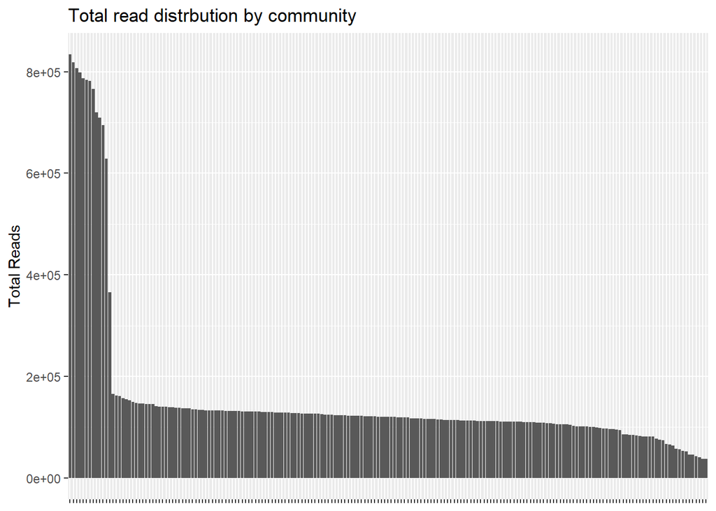

```r
# Plot total distribution of reads

community_reads <- e0026 %>%
  group_by(biosample1) %>%
  summarise(total_reads = sum(as.numeric(count))) %>%
  arrange(desc(total_reads))

community_reads <- data.frame(community_reads)

ggplot(community_reads, aes(x = reorder(biosample1, -total_reads), y = total_reads))+
  geom_histogram(stat="identity")+
  labs(title = "Total read distrbution by community", x= "Community", y = "Total Reads")+
  theme(axis.title.x=element_blank(),
        axis.text.x=element_blank())
```

```r
# Find summary statistics to identify outliers

summary(community_reads)
```

```
##   biosample1         total_reads
##  Length:193         Min.   : 37267
##  Class :character   1st Qu.:108050
##  Mode  :character   Median :120222
##                     Mean   :155727
##                     3rd Qu.:131946
##                     Max.   :834682
```

```r
reads_first_q <- 108050
reads_third_q <- 131946

reads_first_q.data <- filter(community_reads, total_reads < 108050)
```

### Number of strains per community

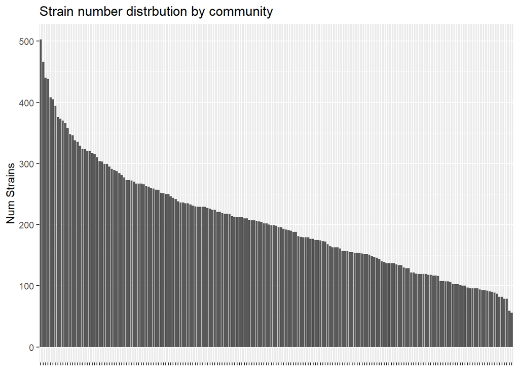

```r
# Instead of adding up the counts, count the rows for that sample

community_strains <- e0026 %>%
  group_by(biosample1) %>%
  summarise(num_strains=n_distinct(OTU))

# Plot the strain number distribution across communities

ggplot(community_strains, aes(x = reorder(biosample1, -num_strains), y = num_strains))+
  geom_histogram(stat="identity")+
  labs(title = "Strain number distrbution by community", x= "Community", y = "Num Strains")+
  theme(axis.title.x=element_blank(),
        axis.text.x=element_blank())
```

```r
summary(community_strains)
```

```
##   biosample1         num_strains
##  Length:193         Min.   : 56.0
##  Class :character   1st Qu.:137.0
##  Mode  :character   Median :198.0
##                     Mean   :203.7
##                     3rd Qu.:257.0
##                     Max.   :503.0
```

```r
strains_first_q <- 52.0
strains_third_q <- 105.25

strains_first_q.data <- filter(community_strains, num_strains < 52)
strains_third_q.data <- filter(community_strains, num_strains > 105.25)

print(strains_first_q.data$biosample1)
```

```
## character(0)
```

```r
print(strains_third_q.data$biosample1)
```

```
##   [1] "XAA-002" "XAA-029" "XAC-002" "XAC-029" "XAC-036" "XAC-064" "XBA-022"
##   [8] "XBA-029" "XBB-022" "XBB-029" "XBB-036" "XCA-001" "XCA-028" "XCA-036"
##  [15] "XCA-064" "XCB-001" "XCB-029" "XCB-036" "XCB-064" "XDA-001" "XDA-029"
##  [22] "XDA-036" "XDA-064" "XDB-001" "XDB-029" "XDB-036" "XDB-064" "XEA-001"
##  [29] "XEA-029" "XEA-036" "XEA-064" "XEB-001" "XEB-029" "XEB-036" "XEB-064"
##  [36] "XFA-001" "XFA-029" "XFA-036" "XFA-064" "XFB-001" "XFB-029" "XFB-036"
##  [43] "XFB-064" "XGA-001" "XGA-029" "XGA-036" "XGA-064" "XGB-001" "XGB-029"
##  [50] "XGB-036" "XGB-064" "XGC-001" "XGC-029" "XGC-037" "XGC-064" "XHA-003"
##  [57] "XHA-029" "XHA-036" "XHA-064" "XHB-001" "XHB-029" "XHB-036" "XHB-064"
##  [64] "XHC-001" "XHC-029" "XHC-036" "XHC-064" "XIA-002" "XIA-029" "XIA-036"
##  [71] "XIA-064" "XIB-002" "XIB-029" "XIB-036" "XIB-064" "XIC-008" "XIC-029"
##  [78] "XIC-036" "XIC-064" "XJA-001" "XJA-029" "XJA-036" "XJA-064" "XKA-001"
##  [85] "XKA-029" "XKB-029" "XKB-036" "XKB-064" "XLA-001" "XLA-029" "XLA-036"
##  [92] "XLA-064" "XLB-001" "XLB-029" "XLB-036" "XLB-064" "XMA-001" "XMB-001"
##  [99] "XMB-029" "XMB-036" "XMB-064" "XNA-001" "XNA-029" "XNA-036" "XNA-064"
## [106] "XNB-001" "XNB-029" "XNB-036" "XNB-064" "XOA-001" "XOA-029" "XOA-036"
## [113] "XOA-064" "XOB-001" "XOB-028" "XOB-037" "XOB-064" "XPA-002" "XPA-029"
## [120] "XPA-036" "XPA-072" "XPB-001" "XPB-028" "XPB-036" "XPB-063" "XQA-001"
## [127] "XQA-029" "XQA-036" "XQA-064" "XQB-001" "XQB-029" "XQB-064" "XRA-029"
## [134] "XRA-064" "XRB-002" "XRB-029" "XRB-036" "XRB-059" "XSA-001" "XSA-029"
## [141] "XSB-001" "XSB-029" "XSB-036" "XSB-064" "XTA-001" "XTA-029" "XTA-036"
## [148] "XTA-064" "XTB-001" "XTB-028" "XTB-037" "XTB-065" "XUA-001" "XUA-029"
## [155] "XUA-036" "XUB-001" "XUB-029" "XUB-036" "XUB-064" "XVA-001" "XVA-029"
## [162] "XVA-036" "XVA-064" "XVB-001" "XVB-027" "XVB-036" "XVB-064" "blank"
```

#### Plot number of reads per family

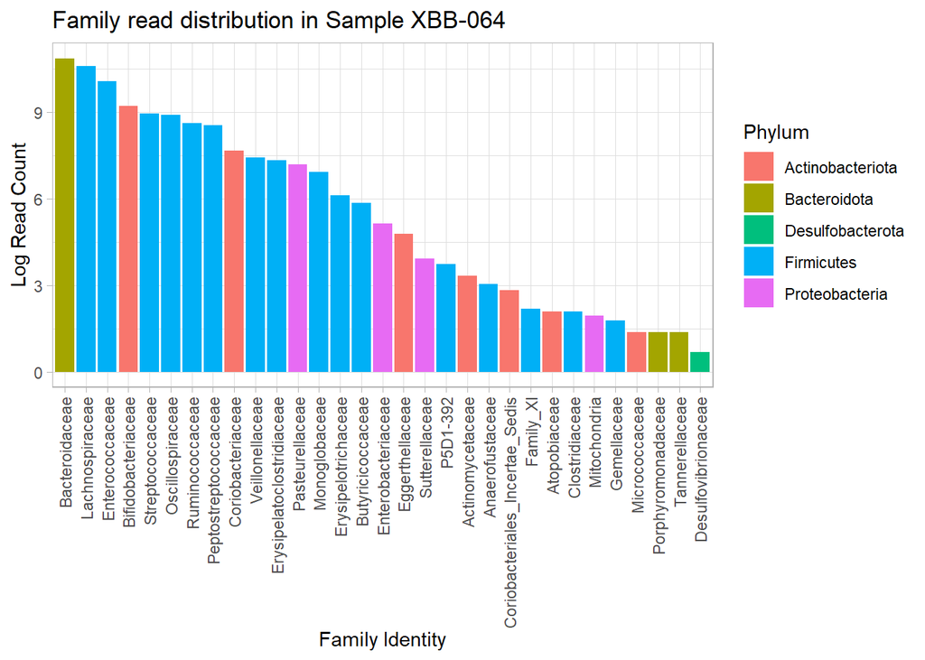

```r
XBB064_household_data <- e0026%>%
  filter(biosample1 == "XBB-064") %>%
  group_by(Phylum, Family) %>%
  summarise(total_reads = sum(as.numeric(count))) %>%
  ggplot(aes(x = reorder(Family, -total_reads), y = log(total_reads), fill=Phylum))+
  geom_bar(stat="identity")+
  labs(title = "Family read distribution in Sample XBB-064", x= "Family Identity", y = "Log Read Count")+
  theme_light()+
  theme(axis.text.x = element_text(angle = 90, vjust = 0.5, hjust=1))
XBB064_household_data
```

#### Plot number of reads per family

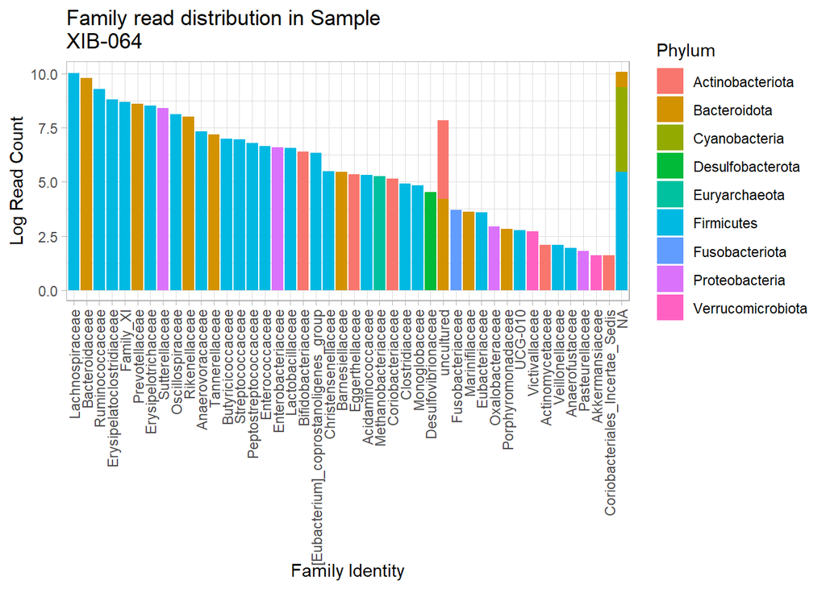

```r
XIB064_household_data <- e0026%>%
  filter(biosample1 == "XIB-064") %>%
  group_by(Phylum, Family) %>%
  summarise(total_reads = sum(as.numeric(count))) %>%
  ggplot(aes(x = reorder(Family, -total_reads), y = log(total_reads), fill=Phylum))+
  geom_bar(stat="identity")+
  labs(title = "Family read distribution in Sample
XIB-064", x= "Family Identity", y = "Log Read Count")+
  theme_light()+
  theme(axis.text.x = element_text(angle = 90, vjust = 0.5, hjust=1))
XIB064_household_data
```

### Compositional changes across passages

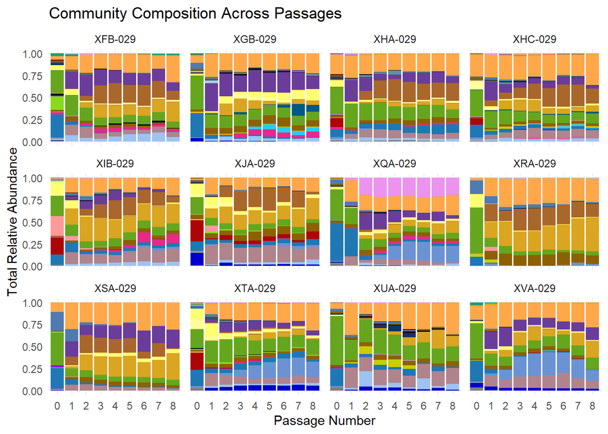

```r
# Extract only communities that have all 0-8 passages sequenced

all_passages <- household_data %>%
  filter(str_detect(household_data$sample, "e0026")) %>%
  group_by(biosample1)  %>%
  mutate(num_passages = n_distinct(passage)) %>%
  filter(num_passages == 9) %>%
  ungroup()


my_colors <- readRDS("C:/Spring-Rotation-2025/scratch/familyColorPalette.rds")

# Plot the total relative abundances (which are calculated per community) totaled up for each

ggplot(all_passages, aes(x = factor(passage), y = relAbundance, fill = Family)) +
  geom_bar(stat = "identity") +
  scale_fill_manual(values = my_colors) +
  labs(title = "Community Composition Across Passages" , x = "Passage Number", y = "Total Relative Abundance", fill = "Family") +
  theme_minimal()+
  theme(
  legend.position = "none"
) +
  facet_wrap(~ biosample1)
```

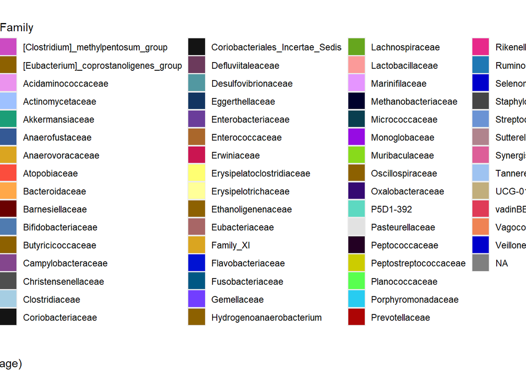

```r
ggsave("composition_across_passages.png", width = 14, height = 12, dpi = 300, bg = "white")

ggplot(all_passages, aes(x = factor(passage), y = relAbundance, fill = Family)) +
  geom_bar(stat = "identity") +
  scale_fill_manual(values = my_colors)
```

Observations:

Which families are most impacted by being in the lab? Which families tend to do much better in vitro than in vivo, and which families tend to do much worse?

***Plot the fold-change (in abundance) of each family in passage 0 versus passage 8 (relative abundance p8 / relative abundance p0 (may need a pseudocounts)) for each subject and day 29 community. Hint: you may need pivot_wider to calculate the fold-change.

```r
# get passage 0 and passage 8 communities for day 29

p0_p8 <- e0026_day29 %>%
  filter(passage %in% c(0, 8)) %>%
  select(biosample1, OTU, count, passage, relAbundance, Family) %>%
  group_by(passage, biosample1, Family) %>%
  summarise(
    total_abundance = sum(relAbundance, na.rm = TRUE),
    .groups = "drop"
  ) %>%
  pivot_wider(
    names_from = passage,
    values_from = total_abundance,
    names_prefix = "relAbundance_passage_"
  )%>%
  replace_na(list(relAbundance_passage_0 = 0, relAbundance_passage_8 = 0)) %>%
  mutate(
    relAbundance_passage_0 = if_else(relAbundance_passage_0 == 0, 1e-4, relAbundance_passage_0),
    relAbundance_passage_8 = if_else(relAbundance_passage_8 == 0, 1e-4, relAbundance_passage_8)
  )

p0_p8_foldchange <- p0_p8 %>%
  mutate(fold_change = relAbundance_passage_8/relAbundance_passage_0)
```

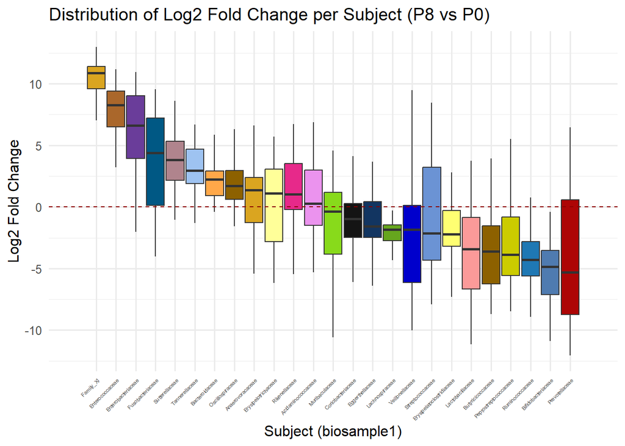

```r
# Filter the full dataset to just top 20 families
filtered_data <- p0_p8_foldchange %>%
  filter(Family %in% top_families)

filtered_data %>%
  mutate(log2_fc = log2(fold_change)) %>%
  ggplot(aes(x = fct_reorder(Family, -log2_fc), y = log2_fc, fill = Family)) +
  geom_boxplot(width = 0.9, outlier.shape = NA) +
  scale_fill_manual(values = my_colors)+
  geom_hline(yintercept = 0, linetype = "dashed", color = "darkred") +
  scale_x_discrete(expand = expansion(mult = c(0.1, 0.1))) +
  labs(
    title = "Distribution of Log2 Fold Change per Subject (P8 vs P0)",
    x = "Subject (biosample1)",
    y = "Log2 Fold Change"
  ) +
  theme_minimal(base_size = 12) +
  theme(axis.text.x = element_text(angle = 45, hjust = 1, size = 4), legend.position = "none")
```

```r
ggsave("fold_change_p0p8.png", width = 14, height = 12, dpi = 300, bg = "white")

# maybe try arranging the boxplots
# or try filtering the families to the top 20
# or extract the 5-letter family code
```

What are the main taxa that are present in our communities? Plot a summary of the most prevalent and abundant taxa across subjects at day 29.

Prevalence is the number (percentage) of samples that contain that family Total abundance is the cumulative abundance of the different strains in a family. The mean abundance is the average between the same families across different subjects.

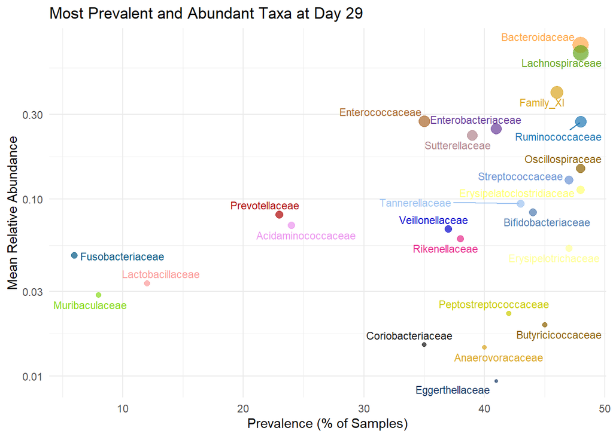

```r
# e0026_day29 <- e0026 %>%   filter(str_detect(biosample1, "029") | str_detect(biosample1, "028") | str_detect(biosample1, "027") | str_detect(biosample1, "022"))


# I want the total relative abundance of OTUs at the family-level first

summary_total_abundance <- e0026_day29 %>%
  group_by(biosample1, Family) %>%
  summarise(
    total_abundance = sum(relAbundance, na.rm = TRUE),
    .groups = "drop"
  )

# Then, I get the mean of those total family abundances across all subjects

summary_mean_abundance <- summary_total_abundance %>%
  group_by(Family) %>%
  summarise(
    prevalence = n_distinct(biosample1[total_abundance > 0.001]),
    mean_abundance = mean(total_abundance, na.rm = TRUE),
    .groups = "drop"
  )

# Adjust prevalence to be the percent of total samples

n_samples <- e0026_day29 %>%
  pull(biosample1) %>% n_distinct()

summary <- summary_mean_abundance %>%
  mutate(prevalence_pct = 100 * prevalence / n_samples)

summary <- summary %>%
  filter(Family %in% top_families)


ggplot(summary, aes(x = prevalence, y = mean_abundance, label = Family, color = Family)) +
  geom_point(aes(size = mean_abundance), alpha = 0.7) +
  geom_text_repel(size = 3, max.overlaps = Inf) +
  scale_color_manual(values = my_colors) +
  scale_x_continuous(name = "Prevalence (% of Samples)") +
  scale_y_continuous(name = "Mean Relative Abundance", trans = "log10") +
  labs(title = "Most Prevalent and Abundant Taxa at Day 29") +
  theme_minimal()+
  theme(
  legend.position = "none"
)
```

```r
ggsave("abundance_prevalence.png", width = 14, height = 12, dpi = 300, bg = "white")
```

Interpretation:

Top right = common and abundant taxa (core microbiome)

Bottom right = common but low-abundance taxa

Top left = rare but abundant in a few subjects

Bottom left = rare and low-abundance

Questions:

Is this the best way to answer this question or to represent the data?

How consistent is the community composition, in the absence of antibiotics? Plot a comparison of community composition at days 1 and 29 (pre-abx).

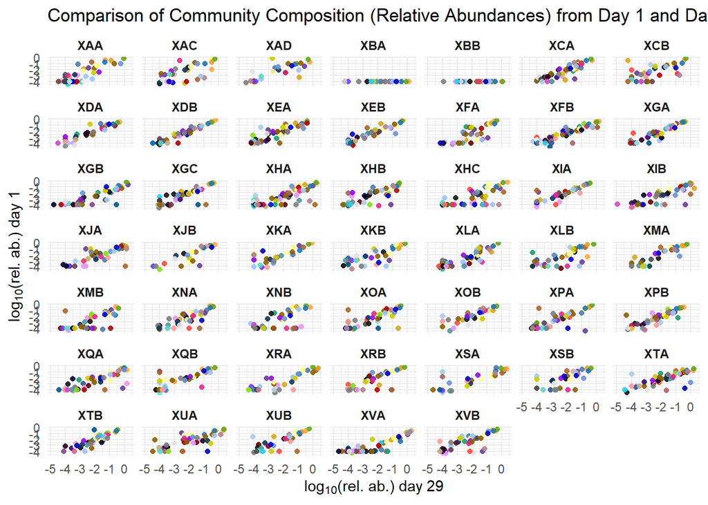

```r
# Get only subject with data from both days. CHECK THIS!!!

subjects_with_both_days <- e0026_clean %>%
  filter(day %in% c("001", "002","003", "022", "027", "028", "029")) %>%
  distinct(subject, day) %>%
  count(subject) %>%
  filter(n == 2) %>%
  pull(subject)

compare_001 <- e0026_clean %>%
  filter(day == "001" | day == "002" | day == "003", subject %in% subjects_with_both_days) %>%
  group_by(subject, Family) %>%
  summarize(total_abundance = sum(relAbundance), .groups = "drop") %>%
  mutate(day = "001")

compare_029 <- e0026_clean %>%
  filter(day == "029" | day == "028" | day == "027" | day == "022", subject %in% subjects_with_both_days) %>%
  group_by(subject, Family) %>%
  summarize(total_abundance = sum(relAbundance), .groups = "drop") %>%
  mutate(day = "029")

# Combine data and create two variables for each day's relative abundance

combined_data_0129 <- bind_rows(compare_001, compare_029)
wide_data <- combined_data_0129 %>%
  pivot_wider(
    names_from = day,
    values_from = total_abundance,
    names_prefix = "day_"
  ) %>%
  replace_na(list(day_001 = 0, day_029 = 0)) %>%
  mutate(
    day_001 = if_else(day_001 == 0, 1e-4, day_001),
    day_029 = if_else(day_029 == 0, 1e-4, day_029)
  )
plot_data <- wide_data %>%
  mutate(
    log_day1 = log10(day_001),
    log_day29 = log10(day_029)
  )


day1_29_composition <- ggplot(plot_data, aes(x = log_day29, y = log_day1, color = Family)) +
  geom_point(size = 1.5, alpha = 0.9) +
  scale_color_manual(values = my_colors) +
  facet_wrap(~ subject) +
  scale_x_continuous(name = expression(log[10]*"(rel. ab.) day 29")) +
  scale_y_continuous(name = expression(log[10]*"(rel. ab.) day 1")) +
  labs(title = "Comparison of Community Composition (Relative Abundances) from Day 1 and Day 29") +
  theme_minimal() +
  theme(
    strip.text = element_text(face = "bold"),
    legend.position = "none"
  )


day1_29_composition
```

```r
# save plot

ggsave("day1_29_composition.png", width = 14, height = 12, dpi = 300, bg = "white")
```

### Species Richness: calculate number of OTU’s with a relative abundance > 0.1%

1.) Plot the distribution of species richness at each timepoint, for abx- and non-abx subjects.

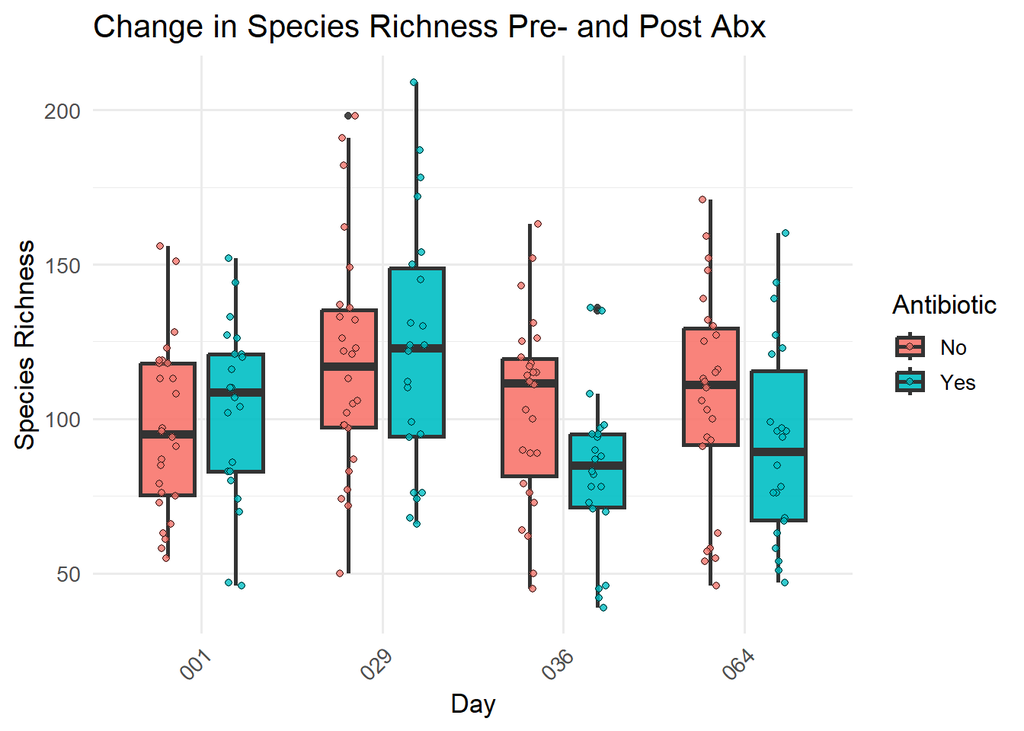

```r
#Plot the distribution of species richness at each time point for samples with and without antibiotic (facet by subject). x: abx vs. non-abx, y:species richnes, faceted by

# Combine all the day datasets

combined_data_richness <- bind_rows(e0026_day1, e0026_day29, e0026_day36, e0026_day64)

# Number of species per sample (rel abundance > 0.001)

e0026_richness <- combined_data_richness %>%
  filter(relAbundance > 0.001) %>%
  select(biosample1, OTU) %>%
  distinct() %>%
  dplyr::count(biosample1, name = "species_richness") %>%
  left_join(
    combined_data_richness %>% distinct(biosample1, day, subject, antibiotic),
    by = "biosample1"
  )


e0026_richness <- e0026_richness %>%
  mutate(
    day = factor(day, levels = sort(unique(day))),
    antibiotic = factor(antibiotic, levels = c(0, 1), labels = c("No", "Yes"))
  )


species_richness_time <- ggplot(
  e0026_richness,
  aes(x = day, y = species_richness, fill = antibiotic)
) +
  geom_boxplot(
    position = position_dodge(width = 0.75),
    width = 0.6,
    alpha = 0.9,
    size = 1
  )  +
  geom_jitter(
    color = "black",
    position = position_jitterdodge(jitter.width = 0.2, dodge.width = 0.75),
    shape = 21,
    stroke = 0.3,
    size = 1.5,
    alpha = 0.8
  ) +
  labs(
    title = "Change in Species Richness Pre- and Post Abx",
    x = "Day",
    y = "Species Richness",
    fill = "Antibiotic"
  ) +
  theme_minimal(base_size = 13) +
  theme(
    legend.position = "right",
    axis.text.x = element_text(angle = 45, hjust = 1)
  )

species_richness_time
```

```r
ggsave("species_richness_time.png", width = 14, height = 12, dpi = 300, bg = "white")
# try running the wilcoxon rank test with
```

How do communities change after antibiotics?

2.) Plot stacked bar plots with a facet for each subject, showing compositional changes over time across timepoints, at passage 8.

```r
combined_data_composition <- bind_rows(e0026_day1, e0026_day29, e0026_day36, e0026_day64)

p8_data <- combined_data_composition %>%
  filter(passage == 8)


# Summarize relative abundance per biosample1 by Family
composition_summary <- p8_data %>%
  group_by(biosample1, Family) %>%
  summarise(relAbundance = sum(relAbundance, na.rm = TRUE), .groups = "drop") %>%
  left_join(
    p8_data %>% distinct(biosample1, day, subject, antibiotic),
    by = "biosample1"
  ) %>%
  mutate(
    day = factor(day, levels = sort(unique(day)))
  )
```

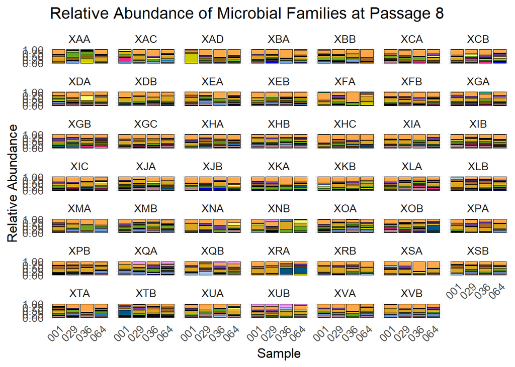

```r
relative_abundance_plot <- ggplot(
  composition_summary,
  aes(x = factor(day), y = relAbundance, fill = Family)
) +
  geom_bar(
    stat = "identity",
    position = "stack",
    color = "black",
    size = 0.2
  ) +
  scale_fill_manual(values = my_colors) +
  facet_wrap(~subject) +
  labs(
    title = "Relative Abundance of Microbial Families at Passage 8",
    x = "Sample",
    y = "Relative Abundance",
    fill = "Family"
  ) +
  theme_minimal(base_size = 13) +
  theme(
    axis.text.x = element_text(angle = 45, hjust = 1),
    legend.position = "none"
  )
relative_abundance_plot
```

```r
ggsave("p8_relative_abundance_plot.png", width = 14, height = 12, dpi = 300, bg = "white")
```

(stretch goal) Which families are the most strongly impacted by antibiotics? ***Plot the fold-change after abx for each ASV in each subject, and plot average fold-change sorted by bacterial family. (this might be like the p8/p0 graph above)

```r
# Filter for day 29 & 36 and only antibiotic-treated subjects
pre_post_abx <- e0026_clean %>%
  filter(day %in% c("029", "036"), antibiotic == 1) %>%
  select(biosample1, subject, day, OTU, relAbundance, Family)

# Summarize relAbundance per OTU per subject per day
pre_post_abx_summary <- pre_post_abx %>%
  group_by(subject, day, OTU, Family) %>%
  summarise(total_abundance = sum(relAbundance, na.rm = TRUE), .groups = "drop") %>%
  pivot_wider(
    names_from = day,
    values_from = total_abundance,
    names_prefix = "relAbundance_day_"
  ) %>%
  replace_na(list(relAbundance_day_029 = 0, relAbundance_day_036 = 0)) %>%
  mutate(
    relAbundance_day_029 = if_else(relAbundance_day_029 == 0, 1e-4, relAbundance_day_029),
    relAbundance_day_036 = if_else(relAbundance_day_036 == 0, 1e-4, relAbundance_day_036),
    fold_change = relAbundance_day_036 / relAbundance_day_029,
    log2_fc = log2(fold_change)
  )
```

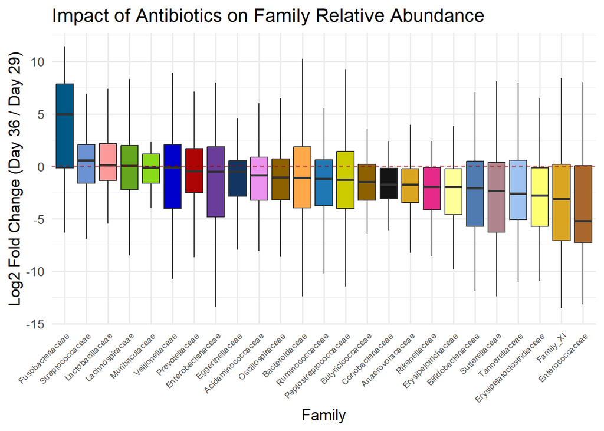

```r
pre_post_abx_summary <- pre_post_abx_summary %>%
  filter(Family %in% top_families)

ggplot(pre_post_abx_summary, aes(x = fct_reorder(Family, -log2_fc), y = log2_fc, fill = Family)) +
  geom_boxplot(outlier.shape = NA, width = 0.8) +
  geom_hline(yintercept = 0, linetype = "dashed", color = "darkred") +
  scale_fill_manual(values = my_colors)+
  labs(
    title = "Impact of Antibiotics on Family Relative Abundance",
    x = "Family",
    y = "Log2 Fold Change (Day 36 / Day 29)"
  ) +
  theme_minimal(base_size = 13) +
  theme(
    axis.text.x = element_text(angle = 45, hjust = 1, size = 7),
    legend.position = "none"
  )
```